# Exercise to prepare for Lesson 2

Author Name

2024-05-24

```r
library(tidyverse)
library(openintro)
```

Materials in this set of exercises is adjusted from https://openintrostat.github.io/ims-tutorials/02-explore/ # Exercise 1: Vizualizing categorical data - Graphical representation of two categorical variables Side-by-side bar charts Stacked bar charts To normalize or not to normalize - Tabular representation of two categorical variables Computation of margins Counts vs proportions Law of total probability - Graphical representation of one categorical variable –Marginal vs conditional –Bar chart –ordering —data integrity check for levels Pie chart

Load data

```r
day <- read.csv("/Users/gote0002/Documents/GitHub/Business-Analytics/Data_sets/bike_sharing/day.csv")
hour <- read.csv("/Users/gote0002/Documents/GitHub/Business-Analytics/Data_sets/bike_sharing/hour.csv")
```

What variables are present in data set “hour”:

```r
names(hour)
```

```
##  [1] "instant"    "dteday"     "season"     "yr"         "mnth"
##  [6] "hr"         "holiday"    "weekday"    "workingday" "weathersit"
## [11] "temp"       "atemp"      "hum"        "windspeed"  "casual"
## [16] "registered" "cnt"
```

Check what variables are present in the data set “day” by substituting the name of the data set from “hour” to “day”. Are there any differences? You can also see the names of the variables when you view the data.

[figure not shown]

```r
ggplot(day, aes(x = dteday, y = cnt, group = 1)) +
  geom_path()
```

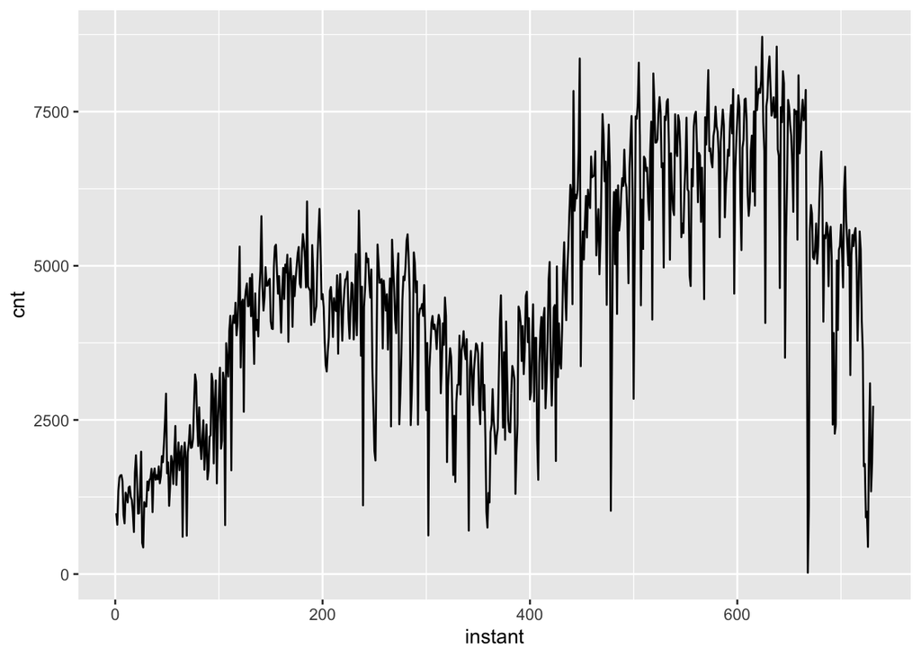

```r
ggplot(day, aes(x = instant, y = cnt, group = 1)) +
  geom_path() # better x axis label, but no meaning
```

# Exercise 2

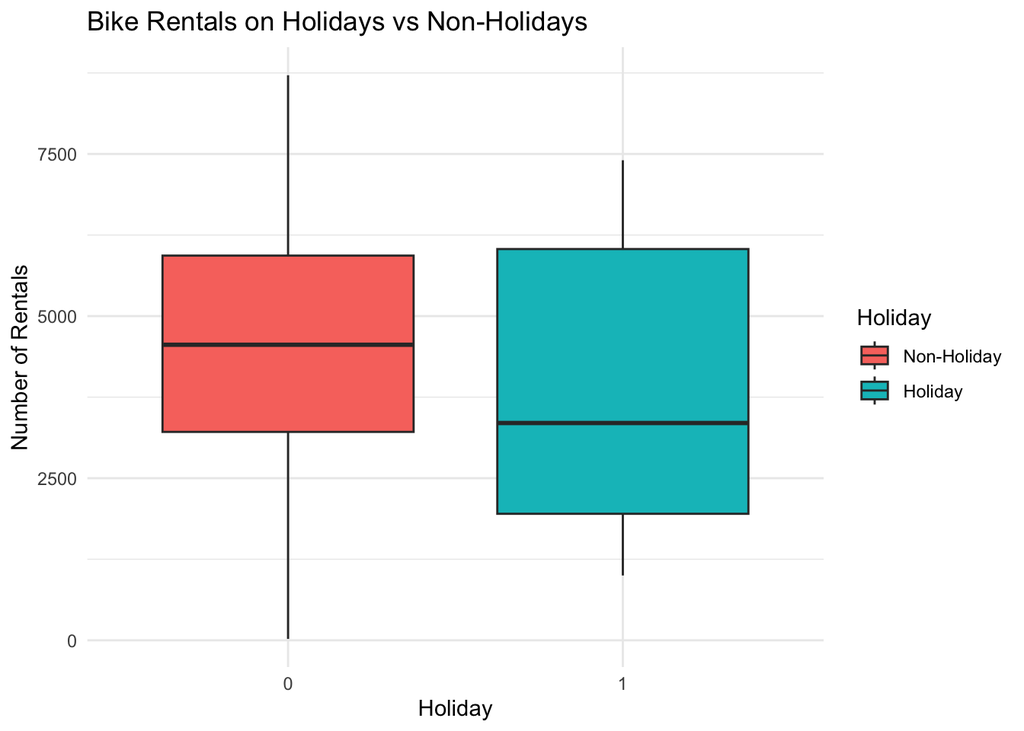

```r
ggplot(data = day, aes(x = factor(holiday), y = cnt, fill = factor(holiday))) +
  geom_boxplot() +
  labs(title = 'Bike Rentals on Holidays vs Non-Holidays', x = 'Holiday', y = 'Number of Rentals', fill = 'Holiday') +
  scale_fill_discrete(labels = c('Non-Holiday', 'Holiday')) +
  theme_minimal()
```

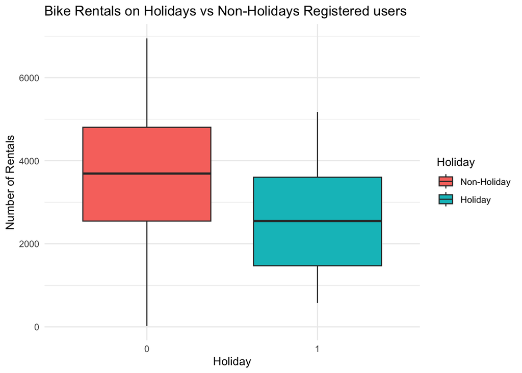

```r
ggplot(data = day, aes(x = factor(holiday), y = registered, fill = factor(holiday))) +
  geom_boxplot() +
  labs(title = 'Bike Rentals on Holidays vs Non-Holidays Registered users', x = 'Holiday', y = 'Number of Rentals', fill = 'Holiday') +
  scale_fill_discrete(labels = c('Non-Holiday', 'Holiday')) +
  theme_minimal()
```

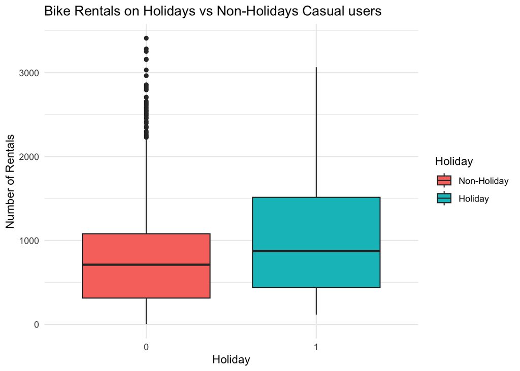

```r
ggplot(data = day, aes(x = factor(holiday), y = casual, fill = factor(holiday))) +
  geom_boxplot() +
  labs(title = 'Bike Rentals on Holidays vs Non-Holidays Casual users', x = 'Holiday', y = 'Number of Rentals', fill = 'Holiday') +
  scale_fill_discrete(labels = c('Non-Holiday', 'Holiday')) +
  theme_minimal()
```

Summaries:

```r
mean(day[day$holiday == 1, "cnt"])
```

```
## [1] 3735
```

```r
sd(day[day$holiday == 1, "cnt"])
```

```
## [1] 2103.351
```

```r
var(day[day$holiday == 1, "cnt"])
```

```
## [1] 4424084
```

Another way to subset the data to only holidays is using the tidyverse package

```r
day_holidays <- day%>%filter(holiday == 1) # filter only those rows observations that are have
mean(day_holidays$cnt)
```

```
## [1] 3735
```

```r
sd(day_holidays$cnt)
```

```
## [1] 2103.351
```

```r
var(day_holidays$cnt)
```

```
## [1] 4424084
```

# Exercise 3

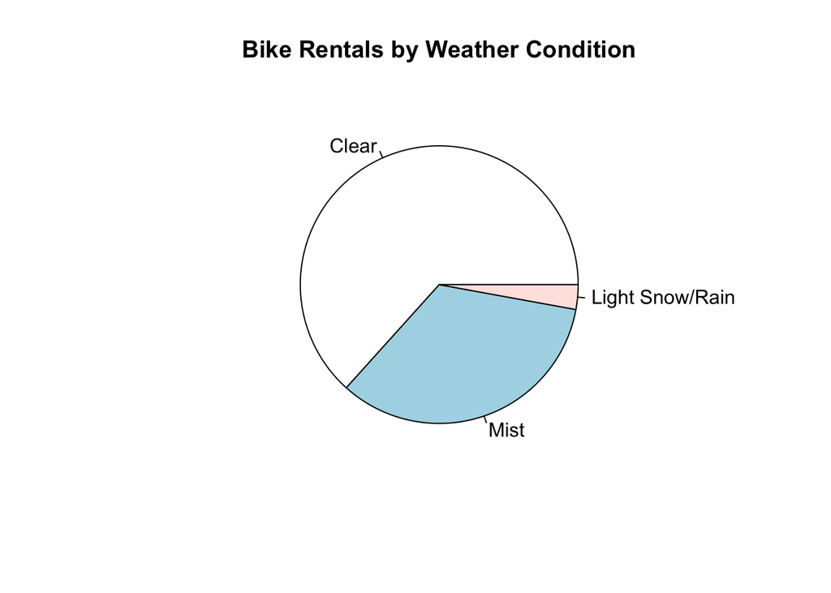

```r
weather_counts <- table(day$weathersit)
weather_labels <- c('Clear', 'Mist', 'Light Snow/Rain', 'Heavy Rain/Snow')
pie(weather_counts, labels = weather_labels, main = 'Bike Rentals by Weather Condition')
```

The description of the file states that there is Heavy Rain + Ice Pallets + Thunderstorm + Mist, Snow + Fog weather. However, we can not see this type of weather from the pie chart. See why: there are not bike rental on these days or the there were no such days during the measurement period?

# Exercise 4

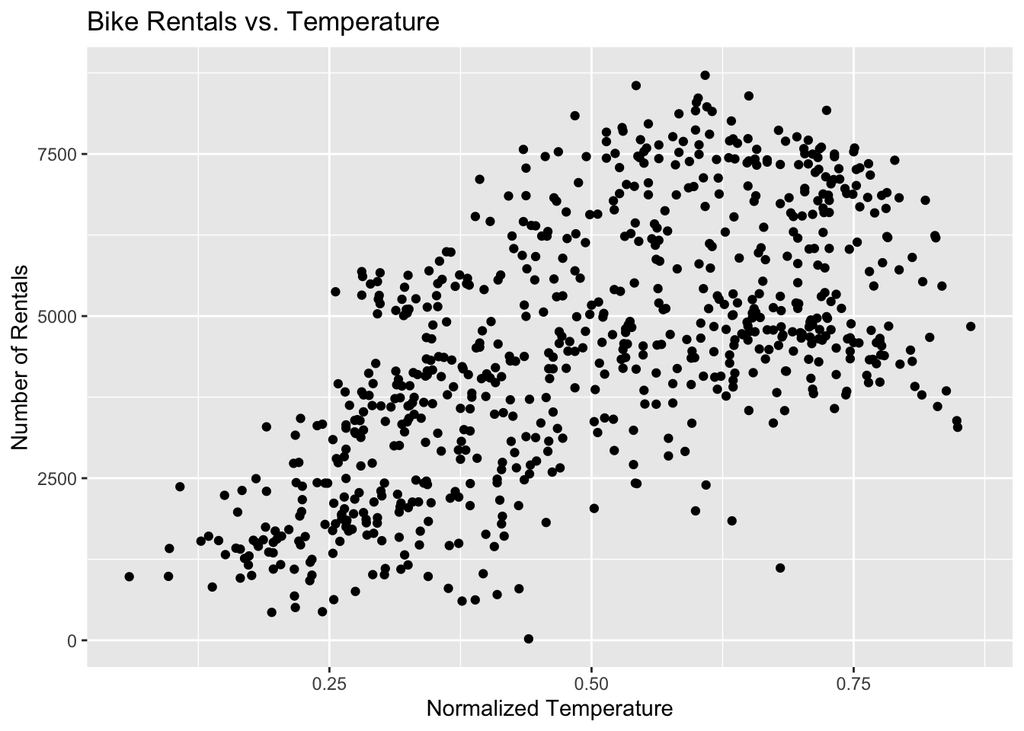

```r
ggplot(day, aes(x = temp, y = cnt)) +
  geom_point() +
  # geom_smooth(method = 'lm') +
  labs(title = 'Bike Rentals vs. Temperature', x = 'Normalized Temperature', y = 'Number of Rentals')
```

```r
cor(day$temp, day$cnt)
```

```
## [1] 0.627494
```

# Exercise 5

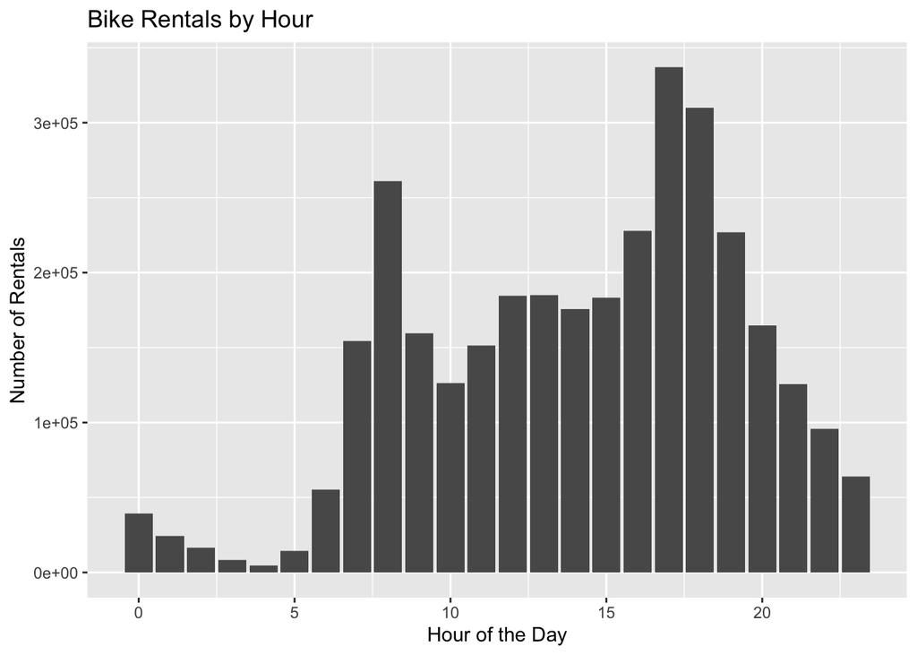

```r
ggplot(hour, aes(x = hr, y = cnt)) +
  geom_histogram(stat = 'identity') +
  labs(title = 'Bike Rentals by Hour', x = 'Hour of the Day', y = 'Number of Rentals')
```

# Exercise 6

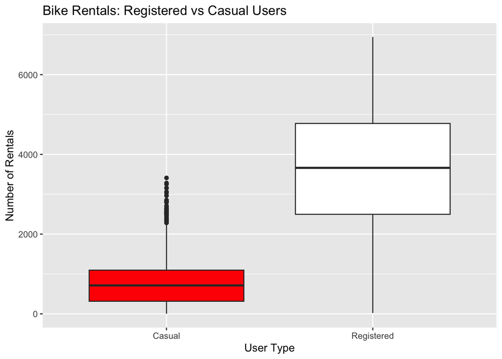

```r
ggplot(day, aes(x = 'Registered', y = registered)) +
  geom_boxplot() +
  geom_boxplot(aes(x = 'Casual', y = casual), fill = 'red') +
  labs(title = 'Bike Rentals: Registered vs Casual Users', x = 'User Type', y = 'Number of Rentals')
```